# Visualización de datos en R

Luz Frias

2016-11-07

# Índice

- Introducción visualización
- Principios básicos
- ggplot
- interactivos
- grafos

# Introducción visualización de datos

- Es parte del análisis exploratorio de los datos
- De un vistazo, podemos entender:
  - Distribuciones
  - Relaciones entre atributos
  - …

# Evitar la distorsión de los datos

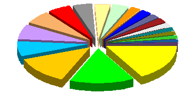

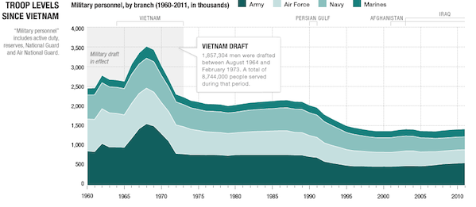

# El contexto de los gráficos

- El gráfico debe servir para apoyar una serie de conclusiones / explicaciones a lo observado

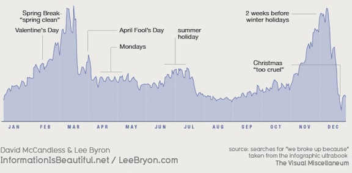

# Un mismo gráfico para exponer varios niveles de detalle

- Combinando formas, colores y posición podemos describir varias dimensiones de la información de un solo vistazo

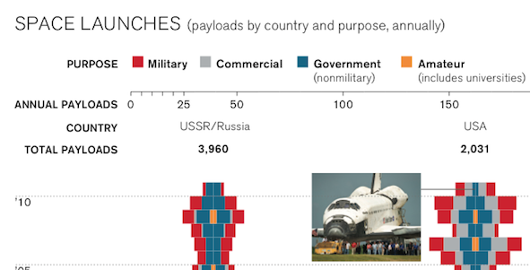

- La dimensión tiempo en los gráficos: [ejemplo](http://www.thomson.co.uk/blog/wp-content/uploads/infographic/interactive-music-map/index.html)

# Los colores

- Es importante escoger una escala que refleje la naturaleza de los datos:
  - Secuencial: refleja progresivamente las diferencias entre poco y mucho. Por ejemplo, los ingresos mensuales medios por barrio.
  - Divergente: tiene naturaleza secuencial, pero interesa destacar los extremos y el punto medio. Por ejemplo, el mapa de intención de voto demócrata vs republicano en EEUU.
  - Cualitativa: refleja categóricas sin orden. Por ejemplo, hombres vs mujeres.
- Es muy complicado elegir bien una escala. Usa herramientas que ya las proporcionan, como [colorbrewer](http://colorbrewer2.org/)

# La escalas

- Naturaleza de la comparación: normal, logarítmica, … [Ejemplo](https://www.researchtrends.com/wp-content/uploads/2012/09/KL2-log-scale.jpg)
- El cero: ¿comparaciones absolutas o relativas? [Ejemplo](http://www.datapine.com/blog/wp-content/uploads/2014/06/Same-Data-Different-Y-Axis-Data-Visualization-Designed-to-Mislead.png)
- Varias escalas: deben usarse bien para evitar confusiones. [Ejemplo](https://www.elsevier.com/__data/assets/image/0015/35043/Figure-2.jpg)

# La importancia del tipo de gráfico

- [Chart suggestion](http://www.cognoschina.net/home/attachment/200912/2/1177_12597621035pTY.png)

# Ejemplos buenos gráficos: ¿por qué?

- [Servicio militar EEUU](http://www.npr.org/2011/07/03/137536111/by-the-numbers-todays-military)
- [Cartograma elecciones UK](http://www.viewsoftheworld.net/wp-content/uploads/2015/05/ukelection2015_mapviews.jpg)
- [Interactivo rutinas](https://podio.com/site/creative-routines)
- [Animación envejecimiento población](http://www.pewresearch.org/files/2014/04/847889448.gif)
- [Tendencias twitter](http://echeloninsights.com/wp-content/uploads/2014/12/theyearinnews20141.png)
- [Pictoline](https://twitter.com/pictoline/status/796541916397576194?lang=en)
- [Elecciones catalanas](http://www.huffingtonpost.es/2015/09/28/elecciones-catalanas-twitter_n_8206438.html)
- [Redes sociales y grafos](https://twitter.com/graphext/status/748119214431543296)

# Ejemplos malos gráficos: ¿qué cambiarías?

- [Categorías empresas](https://www.datanalytics.com/2011/11/08/bump-charts-para-comparar-graficamente-proporciones-entre-periodos/)
- [IEH](https://www.datanalytics.com/2015/04/23/valores-diferentes/)
- [Ejes](https://www.datanalytics.com/2013/09/05/donde-deberian-comenzar-los-ejes/)
- [Pomelos](https://www.datanalytics.com/2013/08/27/el-pomelazo-del-csic/)
- [Proporciones](https://www.datanalytics.com/2013/03/19/mapas-realmente-necesarios/)
- [El engaño](https://www.datanalytics.com/2011/01/31/un-grafico-enganabobos/)

# ggplot

- Basado en [Grammar of Grahpics](https://www.amazon.com/Grammar-Graphics-Statistics-Computing/dp/0387245448)
- Se definen gráficos con instrucciones de alto nivel
- Muy flexible
- El más popular de R

# Grammar of graphics

- Definición de bloques que forman un gráfico. Pueden ser:
  - datos
  - componentes estéticos
  - geometrías
  - transformaciones estadísticas
  - escalas
  - coordenadas
  - posicionamiento
  - facets